# STA141 Final Project

Leying Chang 919814811

2024-03-10

## Abstract

We analyzed the electrophysiological data of mice collected by Steinmetz et al. Firstly, we found through descriptive statistical analysis that the peak number of neurons in different brain regions affects the feedback type of mice. We integrated the peak number of neurons in different brain regions, contrast of the left stimulus and contrast of the right stimulus, into a complete dataset. We built a random forest model by taking the number of peaks, contrast of the left stimulus, contrast of the right stimulus as independent variables, and feedback type as dependent variable. This model can predict test data.

## Introduction

Through the research of Steinmetz et al, we know that the neurons selected for encoding are only found in a small portion of the brain area. These neurons are relatively rare and mainly distributed in the frontal cortex, basal ganglia, superior thalamus, and motor related superior colliculus. They can also be found in two unexpected subcortical structures (midbrain reticular nucleus and ZI). These regions partially overlap with the visual pathway, however, no encoding selected neurons were found in the visual cortex. Researchers further found that the vast majority of neurons encoding selection information in the midbrain prefer contralateral selection, while neurons encoding selection information in the forebrain have no differential response to contralateral and ipsilateral responses. Therefore, the neurons selected for encoding in the forebrain exhibit significant bilateral encoding, while these neurons in the midbrain exhibit unilateral encoding. Therefore, we believe that the number of neurons in brain regions has a significant impact on the selection of mice.

## Exploratory analysis

### Load the data

```r
session=list()
for(i in 1:18){
  session[[i]]=readRDS(paste('./Data/session',i,'.rds',sep=''))
}
```

### Describe the data structures across sessions

Firstly, we count the number of neurons, the number of trials, the stimuli conditions and the feedback types in different sessions.

```r
sapply(session, function(x){length(x$brain_area)})
```

```
##  [1]  734 1070  619 1769 1077 1169  584 1157  788 1172  857  698  983  756  743
## [16]  474  565 1090
```

```r
sapply(session, function(x){length(x$feedback_type)})
```

```
##  [1] 114 251 228 249 254 290 252 250 372 447 342 340 300 268 404 280 224 216
```

```r
lapply(session, function(x){sort(unique(c(x$contrast_left, x$contrast_right)))})
```

```
## [[1]]
## [1] 0.00 0.25 0.50 1.00
##
## [[2]]
## [1] 0.00 0.25 0.50 1.00
##
## [[3]]
## [1] 0.00 0.25 0.50 1.00
##
## [[4]]
## [1] 0.00 0.25 0.50 1.00
##
## [[5]]
## [1] 0.00 0.25 0.50 1.00
##
## [[6]]
## [1] 0.00 0.25 0.50 1.00
##
## [[7]]
## [1] 0.00 0.25 0.50 1.00
##
## [[8]]
## [1] 0.00 0.25 0.50 1.00
##
## [[9]]
## [1] 0.00 0.25 0.50 1.00
##
## [[10]]
## [1] 0.00 0.25 0.50 1.00
##
## [[11]]
## [1] 0.00 0.25 0.50 1.00
##
## [[12]]
## [1] 0.00 0.25 0.50 1.00
##
## [[13]]
## [1] 0.00 0.25 0.50 1.00
##
## [[14]]
## [1] 0.00 0.25 0.50 1.00
##
## [[15]]
## [1] 0.00 0.25 0.50 1.00
##
## [[16]]
## [1] 0.00 0.25 0.50 1.00
##
## [[17]]
## [1] 0.00 0.25 0.50 1.00
##
## [[18]]
## [1] 0.00 0.25 0.50 1.00
```

```r
lapply(session, function(x){as.numeric(unique(x$feedback_type))})
```

```
## [[1]]
## [1]  1 -1
##
## [[2]]
## [1] -1  1
##
## [[3]]
## [1]  1 -1
##
## [[4]]
## [1]  1 -1
##
## [[5]]
## [1]  1 -1
##
## [[6]]
## [1]  1 -1
##
## [[7]]
## [1]  1 -1
##
## [[8]]
## [1]  1 -1
##
## [[9]]
## [1]  1 -1
##
## [[10]]
## [1] -1  1
##
## [[11]]
## [1]  1 -1
##
## [[12]]
## [1]  1 -1
##
## [[13]]
## [1] -1  1
##
## [[14]]
## [1]  1 -1
##
## [[15]]
## [1]  1 -1
##
## [[16]]
## [1]  1 -1
##
## [[17]]
## [1] -1  1
##
## [[18]]
## [1]  1 -1
```

### Explore the neural activities during each trial

Taking the first experiment of the first session as an example, we calculate the peak number of each neuron, and then group them according to the brain region where the neurons are located, and count the peak number of neurons in different brain regions.

```r
spikes <- apply(session[[1]]$spks[[1]], 1, sum)
spikes_df <- data.frame(brain_area = session[[1]]$brain_area, spks = spikes)
spikes_df %>%
  group_by(brain_area) %>%
  summarise(spks = sum(spks))
```

```
## # A tibble: 8 × 2
##   brain_area  spks
##   <chr>      <dbl>
## 1 ACA          138
## 2 CA3          104
## 3 DG            79
## 4 LS           269
## 5 MOs          106
## 6 SUB          156
## 7 VISp         300
## 8 root           9
```

### Explore the changes across trials

Taking the first session as an example, we compare the peak number of neurons in different brain regions through a box plot.

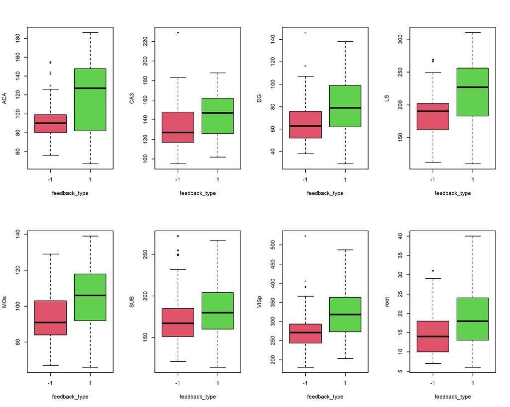

```r
spks_list <- lapply(session[[1]]$spks, function(x){apply(x, 1, sum)})
brain_spks_list <- lapply(spks_list, function(x){
  data.frame(brain_area = session[[1]]$brain_area, spks = x)})
brain_area_spks_list <- lapply(brain_spks_list, function(x){
  x %>% group_by(brain_area) %>% summarise(spks = sum(spks))})
brain_area_spks <- do.call(cbind, brain_area_spks_list)
rownames(brain_area_spks) <- brain_area_spks$brain_area
colnames(brain_area_spks) <- NULL
brain_area_spks <- brain_area_spks[, -seq(1,ncol(brain_area_spks),2)]
brain_area_spks <- as.data.frame(t(brain_area_spks))
brain_area_spks$feedback_type <- as.factor(session[[1]]$feedback_type)
par(mfrow = c(2,4))
for(i in 1:8){
  boxplot(as.numeric(brain_area_spks[,i])~brain_area_spks$feedback_type,
          xlab = "feedback_type", ylab = names(brain_area_spks)[i], col = 2:3)
}
```

### Explore homogeneity and heterogeneity across sessions and mice

```r
brain_area_df <- do.call(rbind, lapply(session, function(x){paste(unique(x$brain_area), collapse = ",")}))
brain_area_df <- data.frame(mouse_name = sapply(session, function(x){x$mouse_name}),
                            area = brain_area_df[,1])
```

## Data integration

We first extract the peak number of different brain regions for each session, type of the feedback, contrast of the left stimulus, contrast of the right stimulus, and the name of the mouse. Next, we will integrate data from different sessions to generate a new data frame, and then replace the missing values with 0.

```r
merge_trial_data <- function(x) {
  brain_area <- session[[x]]$brain_area
  spks_list <- lapply(session[[x]]$spks, function(x){apply(x, 1, sum)})
  brain_spks_list <- lapply(spks_list, function(x){
    data.frame(brain_area = brain_area, spks = x)})
  brain_area_spks_list <- lapply(brain_spks_list, function(x){
    x %>% group_by(brain_area) %>% summarise(spks = sum(spks))})
  brain_area_spks <- do.call(cbind, brain_area_spks_list)
  rownames(brain_area_spks) <- brain_area_spks$brain_area
  colnames(brain_area_spks) <- NULL
  brain_area_spks <- brain_area_spks[, -seq(1,ncol(brain_area_spks),2)]
  brain_area_spks <- t(brain_area_spks)
  df <- cbind(feedback_type = as.numeric(session[[x]]$feedback_type),
              contrast_left = as.numeric(session[[x]]$contrast_left),
              contrast_right = as.numeric(session[[x]]$contrast_right),
              mouse_name = session[[x]]$mouse_name,
              brain_area_spks)
  df <- as.data.frame(t(df))
  df$names <- rownames(df)
  return(df)
}

data <- merge_trial_data(1)

for(i in 2:length(session)) {
  data <- full_join(data, merge_trial_data(i), by = ("names" = "names"), )
}

data <- as.data.frame(t(data))
names(data) <- data[115,]
data <- data[-115,]

data[,c(5:66)] <- lapply(data[,c(5:66)] , function(x){as.numeric(x)})
data <- data %>% mutate(across(c(5:66), replace_na, 0))
head(data)
```

```
##      feedback_type contrast_left contrast_right mouse_name ACA CA3  DG  LS MOs
## V1.x             1             0            0.5       Cori 138 104  79 269 106
## V2.x             1             0              0       Cori  64 116  53 190  88
## V3.x            -1           0.5              1       Cori 130 135 116 240 104
## V4.x            -1             0              0       Cori  56 149  75 147  80
## V5.x            -1             0              0       Cori  84 123  70 181  89
## V6.x             1             0              0       Cori  50 126  36 126  83
##      SUB VISp root CA1 POST VISl VISpm LP MG MRN NB SPF VISam LGd LSr TH VISa
## V1.x 156  300    9   0    0    0     0  0  0   0  0   0     0   0   0  0    0
## V2.x 146  294   12   0    0    0     0  0  0   0  0   0     0   0   0  0    0
## V3.x 198  405   26   0    0    0     0  0  0   0  0   0     0   0   0  0    0
## V4.x 210  278   19   0    0    0     0  0  0   0  0   0     0   0   0  0    0
## V5.x 196  289   14   0    0    0     0  0  0   0  0   0     0   0   0  0    0
## V6.x 143  228   11   0    0    0     0  0  0   0  0   0     0   0   0  0    0
##      VPL OLF ORB PL AUD SSp CP EPd LD PIR ILA PO TT ORBm GPe MB POL SCm SCsg
## V1.x   0   0   0  0   0   0  0   0  0   0   0  0  0    0   0  0   0   0    0
## V2.x   0   0   0  0   0   0  0   0  0   0   0  0  0    0   0  0   0   0    0
## V3.x   0   0   0  0   0   0  0   0  0   0   0  0  0    0   0  0   0   0    0
## V4.x   0   0   0  0   0   0  0   0  0   0   0  0  0    0   0  0   0   0    0
## V5.x   0   0   0  0   0   0  0   0  0   0   0  0  0    0   0  0   0   0    0
## V6.x   0   0   0  0   0   0  0   0  0   0   0  0  0    0   0  0   0   0    0
##      VISrl LSc MOp PT LH MD MS RN SCs ZI PAG RSP BLA VPM SSs MEA RT ACB OT SI
## V1.x     0   0   0  0  0  0  0  0   0  0   0   0   0   0   0   0  0   0  0  0
## V2.x     0   0   0  0  0  0  0  0   0  0   0   0   0   0   0   0  0   0  0  0
## V3.x     0   0   0  0  0  0  0  0   0  0   0   0   0   0   0   0  0   0  0  0
## V4.x     0   0   0  0  0  0  0  0   0  0   0   0   0   0   0   0  0   0  0  0
## V5.x     0   0   0  0  0  0  0  0   0  0   0   0   0   0   0   0  0   0  0  0
## V6.x     0   0   0  0  0  0  0  0   0  0   0   0   0   0   0   0  0   0  0  0
##      SNr
## V1.x   0
## V2.x   0
## V3.x   0
## V4.x   0
## V5.x   0
## V6.x   0
```

## Predictive modeling

We first split 70% of the data as the training set, and then we build a random forest model to predict the test set and calculate the accuracy of the model. Finally, we use all datasets to build a model that will be used for subsequent predictions.

```r
set.seed(1)
index <- sample(1:nrow(data), nrow(data)*0.7)
train <- data[index, ]
test <- data[-index, ]
rf.mod <- randomForest(as.factor(feedback_type)~., train)
rf.pred <- predict(rf.mod, test)
mean(rf.pred == test$feedback_type)
```

```
## [1] 0.7547541
```

```r
final.mod <- randomForest(as.factor(feedback_type)~., data)
```

## Prediction performance on the test sets

```r
t1 <- readRDS("test1.rds")
t2 <- readRDS("test1.rds")
session[[1]] <- t1
session[[18]] <- t2
test1 <- merge_trial_data(1)
test2 <- merge_trial_data(18)
test <- full_join(test1, test2, by = ("names" = "names"))

temp <- data.frame(names = colnames(data))
test <- full_join(test, temp, by = ("names" = "names"))
test <- as.data.frame(t(test))

names(test) <- test[101,]
test <- test[-101,]
test[,c(5:66)] <- lapply(test[,c(5:66)] , function(x){as.numeric(x)})
test <- test %>% mutate(across(c(5:66), replace_na, 0))

final.pred <- predict(final.mod, test)
mean(final.pred == test$feedback_type)
```

```
## [1] 0.79
```

## Discussion

This report explores through data visualization and analyzes the impact of different brain signals on mouse selection. By establishing a model to predict the test set, the performance of the model is good. However, due to method limitations, we did not attempt more machine learning methods and parameter tuning, which may further improve the accuracy of the model if attempted.